# Spatially Adjusted Bayesian Additive Regression Trees Vignette

# Content

In this vignette, 2 examples are shown to demonstrate the usage of this package.

1. A simulation that demonstrate how to fit the model using `wbart_sp` and store the model for prediction use. To do prediction on a new dataset, use S3 method `predict()` on an object of type `wbart_sp` (which is the return of function `wbart_sp`.
2. An example with real PM$_{2.5}$ data in Southern US. Argument `draw_from_total_distribution` and `block` which control how to draw the spatial random effects in the prediction dataset, drawing from the total distribution, or not?

# 1. Simulation

### Define some functions that will be used later

```r
library(ggplot2)
library(BART.sp)
library(matrixStats)
library(dplyr)
library(BART)
library(reshape2)

add_noise_to_the_predicted_value <- function(y_prediction_samples_BART, sigma_vector){
  ndpost <- dim(y_prediction_samples_BART)[1]
  n <- dim(y_prediction_samples_BART)[2]
  sigma <- rep(sigma_vector, each = n)
  noise <- rnorm(n = length(sigma), sd = sigma_vector)
  noise <- matrix(noise, nrow = ndpost, byrow = TRUE)
  return(y_prediction_samples_BART+noise)
}

get_R2 <- function(predicted_y, true_y){
  R2 <- cor(predicted_y, true_y)^2
  return(R2)
}

get_RMSE <- function(predicted_y, true_y){
  RMSE <- sqrt(sum((predicted_y-true_y)^2)/length(true_y))
  return(RMSE)
}

#' @param y a matrix of size m * n, m samples for n observations
#' @param true_y a vector of length n
#' @param cvg a real number between 0 and 1
get_Cvg <- function(y, true_y, cvg = 0.95){
  CI = matrixStats::colQuantiles(y,probs=c(0.5-cvg/2, 0.5+cvg/2))
  Cvg = sum(true_y >= CI[,1] & true_y <= CI[,2] )/length(true_y)
  return(Cvg)
}

corfx <- function(d,theta){
  rho <- exp(theta[1])        # range
  nu  <- exp(theta[2])        # smoothness
  COR <- geoR::matern(d,rho,nu)
  return(COR)
}
```

### Setting up simulation: parameters

```r
# exp
exp_name = 'exp1'
# field: s * s (20, 30*, 40, 50)
s = 30
# monitor density: d (0.05, 0.1*, 0.15)
d = 0.1
# tau2, range, smoothness
#   tau2: 1
my_tau2 = 1
#   range = k3*s (k3: 0.05, 0.1, 0.15) (normal scale)
k3 = 0.1
#   smoothness: -0.3, 0, 0.3 (log scale)
my_smoothness = 0
# num. of observations at each location: n (25, 50*, 100, 150)
n = 50
# sigma2 = k1 * tau2 (k1: 0.5, 1, 2)
k1 = 1
# function
function_num = 6
# training rate of all data: rho (0.3, 0.5, 0.7*, 0.9)
rho = 0.7
# nskip (not a variable)
nskip = 60   # use a larger value when doing real modeling
# ndpost (not a variable)
ndpost = 40   # use a larger value when doing real modeling
# ntree (5, 10*, 15)
ntree = 10
# power (2*, 4, 6)
power = 2
```

### Preparing training and testing datasets

```r
set.seed(998)
my_range = log(k3*s)
my_sigma2 = k1*my_tau2
N = ceiling(s * s * d)  # total number of unique locations
x1 = rnorm(N*n, mean=0, sd=1)
x2 = rnorm(N*n, mean=0, sd=1)
if (function_num == 1) y =  x1
if (function_num == 2) y =  2 * x1
if (function_num == 3) y =  4 * x1
if (function_num == 4) y =  x1 + 2 * x2
if (function_num == 5) y =  x1 * x2
if (function_num == 6) y =  2 * x1 * x2
if (function_num == 7) y =  4 * x2 * x2

xco = runif(n = N, min = -s,  max = s)  # x and y axes (on the ground, not latlon)
yco = runif(n = N, min = -s, max = s)
xyco = cbind(xco,yco)

distanceMatrix = as.matrix (dist( xyco ))
correlationMatrix = corfx(distanceMatrix,c(my_range, my_smoothness))
covarianceMatrix = my_tau2 * correlationMatrix
w.true = as.vector(MASS::mvrnorm (1, mu=rep(0,N), covarianceMatrix)) # spatial random effects
mean(w.true)
```

```
#> [1] -0.2765295
```

```r
# hist(w.true)

# training set
num_training_locations = ceiling(N * rho)
xyco_train = xyco[1:num_training_locations,]
xyco_train_expanded = as.data.frame(cbind(rep(xyco_train[,1], each=n),
                                          rep(xyco_train[,2], each=n)))
training_index = 1:nrow(xyco_train_expanded)
x1_train = x1[training_index]
x2_train = x2[training_index]
if (function_num == 6) training_predictors <- data.frame(x1 = x1_train, x2=x2_train,
                                                         xco = xyco_train_expanded[,1],
                                                         yco = xyco_train_expanded[,2])
y_train =  y[training_index] +
  rep(w.true[1:num_training_locations],each = n) +
  rnorm(nrow(xyco_train),0,sqrt(my_sigma2))
length(y_train)
```

```
#> [1] 3150
```

```r
dim(training_predictors)
```

```
#> [1] 3150    4
```

```r
# testing set
xyco_test = xyco[-(1:num_training_locations),]
xyco_test_expanded = as.data.frame(cbind(rep(xyco_test[,1], each=n),
                                         rep(xyco_test[,2], each=n)))
x1_test = x1[-training_index]
x2_test = x2[-training_index]
if (function_num == 6) testing_predictors <- data.frame(x1 = x1_test, x2=x2_test,
                                                        xco = xyco_test_expanded[,1],
                                                        yco = xyco_test_expanded[,2])
y_test =  y[-training_index] +
  rep(w.true[-(1:num_training_locations)],each = n) +
  rnorm(nrow(xyco_test),0,sqrt(my_sigma2))
length(y_test)
```

```
#> [1] 1350
```

```r
dim(testing_predictors)
```

```
#> [1] 1350    4
```

### Modeling

```r
results_BART <- BART::mc.wbart(x.train = training_predictors,
                       y.train = y_train,
                       nskip = nskip,
                       ndpost = ndpost,
                       ntree = ntree,
                       x.test = testing_predictors)
print(dim(results_BART$sigma))
```

```
#> [1] 80  2
```

```r
print(length(results_BART$sigma))
```

```
#> [1] 160
```

```r
names(xyco_train_expanded) <- c('x','y')
names(xyco_test_expanded) <- c('x','y')
results_BARTsp <- BART.sp::wbart_sp(mc=TRUE,mc.cores=2,
                             x_train = training_predictors,
                             y_train = y_train,
                             coordinates_train = xyco_train_expanded,
                             coordinates_system = 'ground',
                             nskip = nskip,
                             ndpost = ndpost,
                             ntree = ntree,
                             power = power,
                             x_test= testing_predictors,
                             coordinates_test = xyco_test_expanded,
                             tau2_prior_a=3,
                             tau2_prior_b=1,
                             tau2_init=0.1,
                             logrange_init=1.0,
                             logsmoothness_init=0.0,
                             logrange_select_sd=0.5, logsmoothness_select_sd=0.5,
                             sigma2_prior_a=10.0,
                             sigma2_prior_b=1.0,
                             logrange_prior_mean = 0.6,
                             logrange_prior_sd = 0.5,
                             logsmoothness_prior_mean=0.0,
                             logsmoothness_prior_sd=0.5)
print(dim(results_BARTsp$sigma))
```

[output not shown]

```r
print(length(results_BARTsp$sigma))
```

```
#> [1] 40
```

### Evaluation

```r
y_prediction_BART <- results_BART$yhat.test.mean
y_prediction_BARTsp <- colMeans(results_BARTsp$yhat.test)

(R2_BART = get_R2(y_prediction_BART, y_test))
```

```
#> [1] 0.3583928
```

```r
(R2_BARTsp = get_R2(y_prediction_BARTsp, y_test))
```

```
#> [1] 0.6128445
```

```r
(RMSE_BART = get_RMSE(y_prediction_BART, y_test))
```

```
#> [1] 1.922613
```

```r
(RMSE_BARTsp = get_RMSE(y_prediction_BARTsp, y_test))
```

```
#> [1] 1.476141
```

```r
(Cvg_BART = get_Cvg(add_noise_to_the_predicted_value(results_BART$yhat.test,
                                                    c(results_BART$sigma[(nskip+1):
                                                           (nskip+ndpost/2),1],
                                                      results_BART$sigma[(nskip+1):
                                                           (nskip+ndpost/2),2])),
                   y_test))
```

```
#> [1] 0.917037
```

```r
(Cvg_BARTsp = get_Cvg(add_noise_to_the_predicted_value(results_BARTsp$yhat.test,
                                                      results_BARTsp$sigma),
                     y_test))
```

```
#> [1] 0.9659259
```

### Examining estimated spatial random effects

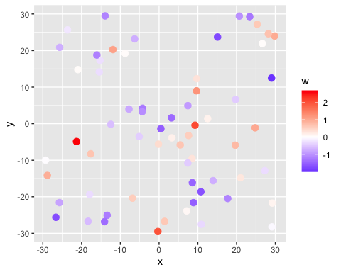

```r
df <- cbind(results_BARTsp$unique_train_locations,
            w=colMeans(results_BARTsp$unique_w))
options(repr.plot.width = 1, repr.plot.height = 0.75)
ggplot(df, aes(x=x, y=y, color=w)) +
    geom_point(size=3)  + scale_color_gradient2(low="blue", mid="white",
                     high="red")
```

We can see some spatial trend in the above figure. The range parameter seems to be quite small (where BARTsp is particularly better than the original BART).

### Examining parameter estimations

```r
mean(results_BARTsp$logrange); my_range
```

```
#> [1] 0.7008515
#> [1] 1.098612
```

```r
mean(results_BARTsp$logsmoothness); my_smoothness
```

```
#> [1] -0.09444473
#> [1] 0
```

```r
mean(results_BARTsp$tau2); my_tau2
```

```
#> [1] 1.045021
#> [1] 1
```

```r
mean(results_BARTsp$sigma^2); my_sigma2
```

```
#> [1] 2.247405
#> [1] 1
```

A better estimation could be achieved with larger burn ins and keeps.

# 2. PM$_{2.5}$ example

### Modeling

Dataset `pm25` (see documentation for this dataset) is shipped with this package.

```r
data(pm25, package='BART.sp')
dim(pm25)
```

```
#> [1] 5000   16
```

```r
head(pm25)
```

```
#>       pm25_value day elevation forest_2006 highway_length limi_highway_length
#> 5337    7.952083  50   93.6147   0.1176470      1089.2306                   0
#> 15772  12.275000 144  178.1230   0.1675580         0.0000                   0
#> 8436    6.237500   2   48.2756   0.1354720       382.6753                   0
#> 13843  10.400000 139   73.6901   0.0000000       643.3110                   0
#> 18874   9.995833 247  244.8790   0.0775401         0.0000                   0
#> 14763  20.450000 224  186.5510   0.3893480         0.0000                   0
#>       local_length sum_emissi_2008 nldas_rh2m nldas_tmp2m narr_hpbl aod_value
#> 5337       0.00000               0    55.5342     283.629   825.989 0.0664025
#> 15772      0.00000               0    59.0107     303.683  1481.630 0.3063325
#> 8436      57.72292               0    48.7858     276.061  1161.590 0.0654835
#> 13843   1173.90647               0    52.2908     301.236  2013.900 0.3153732
#> 18874   1391.04781               0    30.8472     299.916  1800.930 0.0730530
#> 14763   1013.58018               0    52.3143     307.271  1697.760 0.3292101
#>       windspeed    CMAQ    pm_lon   pm_lat
#> 5337  2.0887505 28.1740 -83.59750 32.60428
#> 15772 1.4937616 11.1890 -86.98104 34.51540
#> 8436  6.1453964 12.7470 -82.02277 33.43479
#> 13843 2.7908526  8.3893 -81.02935 33.98853
#> 18874 3.8368411  5.5244 -81.15088 35.25347
#> 14763 0.2672041 11.6950 -85.32790 34.25836
```

```r
locations <- pm25[,c('pm_lon','pm_lat')]
unique_locations <- unique(locations)
dim(unique_locations)
```

```
#> [1] 101   2
```

```r
unique_locations$id <- 1:nrow(unique_locations)
locations <- dplyr::left_join(locations, unique_locations,
                              sorted=FALSE)
pm25 <- dplyr::rename(pm25, c("lon"="pm_lon", "lat"="pm_lat"))
pm25_train <- pm25[locations$id %in% 1:51 ,]
pm25_test <- pm25[locations$id %in% 52:101 ,]

nskip = 1000
ndpost = 2000
ntree = 5
power = 2
model <- BART.sp::wbart_sp(mc=TRUE,mc.cores=2,
                             x_train = pm25_train[,2:ncol(pm25_train)],
                             y_train = pm25_train$pm25_value,
                             coordinates_train = pm25_train[,c('lon','lat')],
                             coordinates_system = 'lonlat',
                             nskip = nskip,
                             ndpost = ndpost,
                             ntree = ntree,
                             power = power)

names(model)
```

```
#>  [1] "sigma"                  "yhat.train.mean"        "yhat.train"
#>  [4] "yhat.test.mean"         "varcount"               "varprob"
#>  [7] "tau2"                   "logrange"               "logsmoothness"
#> [10] "what.train"             "treedraws"              "nskip"
#> [13] "ndpost"                 "sigma_all"              "unique_w"
#> [16] "unique_train_locations" "proc.time"              "coordinates_system"
#> [19] "mu"                     "fhat.train"             "rm.const"
```

```r
dim(model$unique_train_locations)
```

```
#> [1] 51  2
```

```r
dim(model$unique_w)
```

```
#> [1] 2000   51
```

### prediction with `draw_from_total_distribution=TRUE`

```r
predictions <- predict(model,
                      newdata = pm25_test,
                      newloc = pm25_test[,c('lon','lat')],
                      draw_from_total_distribution = TRUE
                      )
names(predictions)
```

```
#> [1] "yhat.test"             "fhat.test"             "what.test"
#> [4] "unique_w_test"         "unique_test_locations"
```

```r
sapply(X=predictions,FUN = dim)
```

```
#>      yhat.test fhat.test what.test unique_w_test unique_test_locations
#> [1,]      2000      2000      2000          2000                    50
#> [2,]      1652      1652      1652            50                     2
```

### prediction with `draw_from_total_distribution=FALSE` and `block`

```r
predictions2 <- predict(model,
                      newdata = pm25_test,
                      newloc = pm25_test[,c('lon','lat')],
                      draw_from_total_distribution = FALSE,
                      block=5
                      )
```

```
#> 50 unique locations, block size: 5 , 10 folds
#> fold 1 / 10
#> fold 2 / 10
#> fold 3 / 10
#> fold 4 / 10
#> fold 5 / 10
#> fold 6 / 10
#> fold 7 / 10
#> fold 8 / 10
#> fold 9 / 10
#> fold 10 / 10
```

```r
names(predictions2)
```

```
#> [1] "yhat.test"             "fhat.test"             "what.test"
#> [4] "unique_w_test"         "unique_test_locations"
```

```r
sapply(predictions2, FUN=dim)
```

```
#>      yhat.test fhat.test what.test unique_w_test unique_test_locations
#> [1,]      2000      2000      2000          2000                    50
#> [2,]      1652      1652      1652            50                     2
```

Comparing the predictions from `draw_from_total_distribution=TRUE` and `draw_from_total_distribution=FALSE`.

```r
pred_w_1 <- cbind(predictions$unique_test_locations,
                  w1=colMeans(predictions$unique_w_test))
pred_w_2 <- cbind(predictions2$unique_test_locations,
                  w2=colMeans(predictions2$unique_w_test))
pred_w <- dplyr::left_join(pred_w_1,
                           pred_w_2,
                           by=c('lon','lat'),
                           sorted=FALSE)

cor(colMeans(predictions2$yhat.test),colMeans(predictions$yhat.test),)
```

```
#> [1] 0.9999948
```

```r
cor(colMeans(predictions2$what.test),colMeans(predictions$what.test),)
```

```
#> [1] 0.8491387
```

```r
cor(pred_w$w1, pred_w$w2)
```

```
#> [1] 0.8929725
```

The estimation of `w` is similar (correlation approximately equals to 0.9).